# Practical 5

Vahe Avagyan Mathematical & Statistical Methods group – Biometris Wageningen University & Research **Linear and Generalized Linear Models** vahe.avagyan@wur.nl

### Packages

First, you need install and load the required R packages.

```r
## Set working directory to convenience
setwd(" ")

## Packages (install and invoke)
pkgs <- rownames(installed.packages())
if(!"bcgam" %in% pkgs) install.packages("bcgam")
if(!"car" %in% pkgs) install.packages("car")
if(!"faraway" %in% pkgs) install.packages("faraway")
```

The code recognizes if certain packages are missing from your package library and, if so, will install them automatically.

Now, we need to load the packages:

```r
library(bcgam)
library(car)
library(faraway)
```

## Exercise 1.

### t-distribution

If Z has a standard-normal distribution and $X^2$, independent from Z, has a Chi-square distribution with $\nu$ degrees of freedom, then $t=\frac{Z}{\sqrt{X^2/\nu}}$ has $t_\nu$ distribution.

Check this by sampling 1000 times a standard normally distributed variable and a Chi-square distributed variable, forming the ratio.

1. Plot the resulting histogram of the t-distributed random variable. Compare the histogram with the theoretical t-distribution. Use df $\nu=4$.
2. Now provide the historgram with $\mu=25$ **Answer**

t-distribution with 4 df:

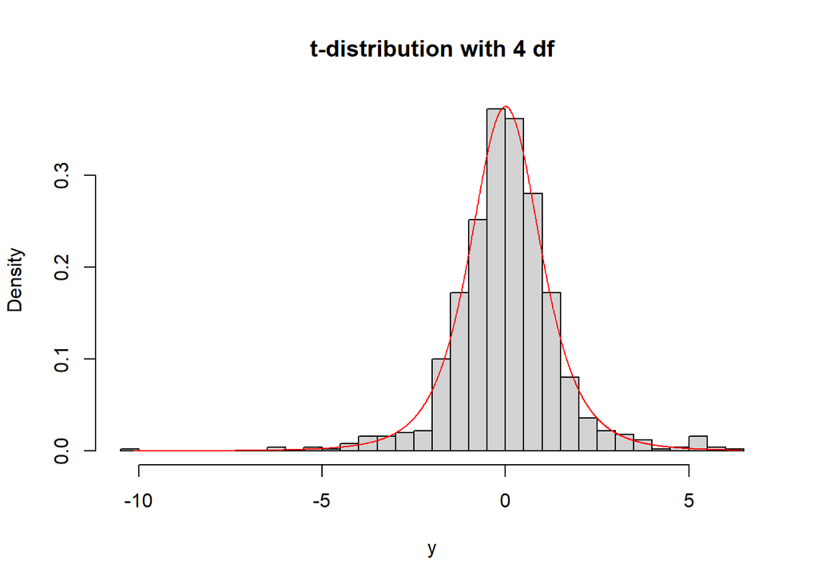

```r
df <- 4
Z <- rnorm(1000)
chisq <- rchisq(1000, df)
y <- Z / sqrt(chisq/df)
hist(y, prob=TRUE, breaks=30, main="t-distribution with 4 df")
x <- seq(min(y), max(y), by=0.01)
d <- dt(x,df)
lines(d ~ x, type="l", col="red")
```

t-distribution with 25 df:

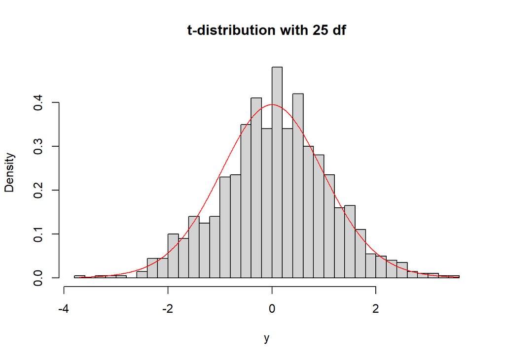

```r
df <- 25
Z <- rnorm(1000)
chisq <- rchisq(1000, df)
y <- Z / sqrt(chisq/df)
hist(y, prob=TRUE, breaks=30, main="t-distribution with 25 df")
x <- seq(min(y), max(y), by=0.01)
d <- dt(x,df)
lines(d ~ x, type="l", col="red")
```

### F-distribution

If $X_1^2$ and $X^2_2$ are independent Chi-square distributed variables with $\nu_1$ and $\nu_2$ degrees of freedom, respectively, then $F={(X^2_1/\nu_1)}/{(X^2_2/\nu_2)}$ has an F-distribution with $\nu_1$ numerator df and $\nu_2$ denominator df. Check this sampling 1000 times from two Chi-square distributions, forming the ratios.

1. Plot the resulting histogram with 4 and 25 df’s. Compare the histogram with the theoretical F-distributions.
2. What is the mean of the F-distributed random variable? Compare it to the expected value (see the slides).

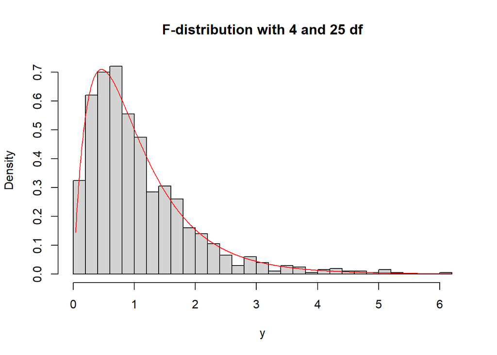

```r
 df1 <- 4; df2 <- 25
 chisq1 <- rchisq(1000, df1)
 chisq2 <- rchisq(1000, df2)
 y <- (chisq1/df1) / (chisq2/df2)
 hist(y, prob=TRUE, breaks=30, main="F-distribution with 4 and 25 df")
 x <- seq(min(y), max(y), by=0.01)
 d <- df(x,df1, df2)
 lines(d ~ x, type="l", col="red")
```

```r
 mean(y)
```

```
## [1] 1.077522
```

## Exercise 2.

Let’s illustrate the F-tests using an economic dataset (called `savings`) on 50 different countries (Faraway). These data are averages over 1960-1970 (to remove business cycle or other short-term fluctuations). `dpi` is per-capita disposable income in U.S. dollars; `ddpi` is the percent rate of change in per capita disposable income; `sr` is aggregate personal saving divided by disposable income. The percentage population under 15 (`pop15`) and over 75 (`pop75`) are also recorded. The data come from Belsley, Kuh, and Welsch (1980).

```r
 data(savings)
```

Regress `sr` against `pop15`, `pop75`, `dpi`, `ddpi`.

$$y_{sr} = \beta_0 + \beta_1 X_{pop15} +
\beta_2 X_{pop75} + \beta_3 X_{dpi} + \beta_4 X_{ddpi} +
\epsilon$$

1. Write down the estimated model with all the predictors.
2. Provide all the steps for the omnibus (i.e., global) F-test. What is your conclusion?
3. Provide the confidence interval for $\beta_1$ (coefficient of `pop15`). Use the manual calculation and compare it to the outcome of R.
4. Give the predicted `sr` for a new country with the values $pop15 = 30$, $pop75 = 2.5$, $dpi = 2000$, $ddpi =4$. Provide the confidence interval for the predicted average savings rate and the prediction interval for an individual savings rate for a new coutry with specified predictors. Use the R code `predict()` to calculate the results. Use the formula in the lecture notes for the manual calculations and compare the results. Which interval is wider and why?
5. Now, construct a reduced model with only `pop15`, `dpi`. Compare the reduced model with the full model. Again, provide all the steps for the F-test and give your conclusion.
6. Suppose that in the full model, we might hypothesize that the effect of young and old people on the savings rate was the same, i.e., $H_0: \beta_{1} = \beta_{2}$. Write down the corresponding model, if $H_0$ is true. Is the hypothesis meaningful?
7. Use R to perform the hypothesis in f) (hint: use `I(pop15 + pop75)` in your model).

**Answer**

```r
SavingsReg <- lm(sr ~ pop15 + pop75 + dpi + ddpi, data=savings)
 summary(SavingsReg)
```

```
##
## Call:
## lm(formula = sr ~ pop15 + pop75 + dpi + ddpi, data = savings)
##
## Residuals:
##     Min      1Q  Median      3Q     Max
## -8.2422 -2.6857 -0.2488  2.4280  9.7509
##
## Coefficients:
##               Estimate Std. Error t value Pr(>|t|)
## (Intercept) 28.5660865  7.3545161   3.884 0.000334 ***
## pop15       -0.4611931  0.1446422  -3.189 0.002603 **
## pop75       -1.6914977  1.0835989  -1.561 0.125530
## dpi         -0.0003369  0.0009311  -0.362 0.719173
## ddpi         0.4096949  0.1961971   2.088 0.042471 *
## ---
## Signif. codes:  0 '***' 0.001 '**' 0.01 '*' 0.05 '.' 0.1 ' ' 1
##
## Residual standard error: 3.803 on 45 degrees of freedom
## Multiple R-squared:  0.3385, Adjusted R-squared:  0.2797
## F-statistic: 5.756 on 4 and 45 DF,  p-value: 0.0007904
```

. P-value is much smaller than 0.05, so $H_0$ is rejected. At least one of the four regressors is related to savings rate.

Some useful R-codes

```r
(TSS <- sum((savings$sr-mean(savings$sr))^2)) #Total SS
```

```
## [1] 983.6283
```

```r
(RSS <- sum(SavingsReg$residuals^2)) # Residual SS
```

```
## [1] 650.713
```

```r
(RegSS <- TSS - RSS) #Regression SS
```

```
## [1] 332.9153
```

```r
(F <- ((RegSS)/4)/(RSS/45)) # Test statistic
```

```
## [1] 5.755681
```

```r
pf(F,4,45, lower.tail = FALSE)
```

```
## [1] 0.0007903779
```

```r
newX <- data.frame(pop15 = 30, pop75=2.5, dpi = 2000, ddpi = 4)
#Confidence interval
pr1 <- predict(SavingsReg, newdata = newX, interval = "confidence",se.fit=TRUE)
pr1$fit
```

```
##        fit      lwr      upr
## 1 11.46652 9.475401 13.45765
```

```r
#Prediction interval
pr2 <- predict(SavingsReg, newdata = newX, interval = "prediction",se.fit=TRUE)
pr2$fit
```

```
##        fit      lwr      upr
## 1 11.46652 3.552968 19.38008
```

```r
#Manual calculation of the predicted value
coef(SavingsReg)[1] + coef(SavingsReg)[2]*30 +
  coef(SavingsReg)[3]*2.5 +  coef(SavingsReg)[4]*2000 +
  coef(SavingsReg)[5]*4
```

```
## (Intercept)
##    11.46652
```

4. The predicted savings rate is $11.466$, with $CI=(9.47; 13.45)$ and $PI=(3.55; 19.38)$. Now let’s calculate the intervals manually.

```r
#New x_star
newX <- as.vector(c(1, 30, 2.5, 2000, 4))

#Manual calculations
X_sr <- model.matrix(SavingsReg)
#Standard error of the average response
(se_mu <- summary(SavingsReg)$sigma * sqrt(t(newX)%*%solve(t(X_sr)%*%X_sr)%*%(newX)))
```

```
##           [,1]
## [1,] 0.9885903
```

```r
pr1$se.fit
```

```
## [1] 0.9885903
```

```r
c(pr1$fit[1]  - qt(0.025, pr1$df, lower.tail = FALSE)*se_mu,
  pr1$fit[1] + qt(0.025, pr1$df, lower.tail = FALSE)*se_mu)
```

```
## [1]  9.475401 13.457647
```

```r
se_ind <- sqrt(pr1$se.fit^2 + pr1$residual.scale^2)

c(pr1$fit[1]  - qt(0.025, pr1$df, lower.tail = FALSE)*se_ind,
  pr1$fit[1] + qt(0.025, pr1$df, lower.tail = FALSE)*se_ind)
```

```
## [1]  3.552968 19.380079
```

```r
data.frame(se_mu, se_ind)
```

```
##       se_mu   se_ind
## 1 0.9885903 3.929071
```

The results are the same as with the `predict()` function. We can see that the prediction interval is wider than the confidence interval. This is because the standard error of the individual prediction is larger than the standard error of the average prediction. A prediction interval is always wider than a confidence interval, because there is more uncertainty around the savings rate of a single country as opposed to the mean savings rate of all countries with the specified $x$-values.

5. The reduced model has the following form:

$$y_{sr} = \beta_0 + \beta_1 X_{pop15} +
\beta_3 X_{dpi} + \epsilon$$

```r
SavingsReg0 <- lm(sr ~ pop15 + dpi , data=savings)
 summary(SavingsReg0)
```

```
##
## Call:
## lm(formula = sr ~ pop15 + dpi, data = savings)
##
## Residuals:
##     Min      1Q  Median      3Q     Max
## -8.1167 -2.6564 -0.0053  1.4831 10.9760
##
## Coefficients:
##               Estimate Std. Error t value Pr(>|t|)
## (Intercept) 22.7126386  4.1520364   5.470 1.69e-06 ***
## pop15       -0.3303269  0.0949204  -3.480  0.00109 **
## dpi         -0.0013107  0.0008767  -1.495  0.14159
## ---
## Signif. codes:  0 '***' 0.001 '**' 0.01 '*' 0.05 '.' 0.1 ' ' 1
##
## Residual standard error: 3.979 on 47 degrees of freedom
## Multiple R-squared:  0.2435, Adjusted R-squared:  0.2113
## F-statistic: 7.564 on 2 and 47 DF,  p-value: 0.001419
```

*The following steps are required for the F-test*

1. $H_0: \beta_2 = \beta_3 = 0$ vs $H_a$: at least one is not zero
2. Test statistic is $F = {\left((RSS_{RM} - RSS_{FM})/2/\right)} / {\left(RSS_{FM}/45\right)}$
3. Under $H_0$, F has $F_{2;45}$ distribution
4. Under $H_a$ F tends to larger values than prescribed by the $F_{2;45}$ distribution
5. Therefore, right-tailed P-value is needed.
6. Outcome: $F = {\left((RSS_{RM} - RSS_{FM})/2/\right)} / {\left(RSS_{FM}/45\right)} = {\left((744.12 - 650.71)/2/\right)} / {\left(650.71/45\right)} = 3.22$.
7. $P = P(F \ge 3.22) = 0.048$

P-value is smaller than 0.05, so $H_0$ is rejected. At least one of the 2 regressors is significantly different than 0. In other words, the full model is better than the reduced model.

Some useful R-codes

```r
(RSS <- sum(SavingsReg$residuals^2)) # Residual SS of the full model
```

```
## [1] 650.713
```

```r
(RSS0 <- sum(SavingsReg0$residuals^2)) # Residual SS of the reduced model
```

```
## [1] 744.1237
```

```r
(F <- ((RSS0 - RSS)/2)/(RSS/45)) # Test statistic
```

```
## [1] 3.229904
```

```r
pf(F,2,45, lower.tail = FALSE)
```

```
## [1] 0.04889312
```

A somewhat more convenient way to compare two nested models is

```r
 anova(SavingsReg, SavingsReg0)
```

```
## Analysis of Variance Table
##
## Model 1: sr ~ pop15 + pop75 + dpi + ddpi
## Model 2: sr ~ pop15 + dpi
##   Res.Df    RSS Df Sum of Sq      F  Pr(>F)
## 1     45 650.71
## 2     47 744.12 -2   -93.411 3.2299 0.04889 *
## ---
## Signif. codes:  0 '***' 0.001 '**' 0.01 '*' 0.05 '.' 0.1 ' ' 1
```

The model under $H_0$ has the following (reduced) form:

$$y_{sr} = \beta_0 + \beta_1 (X_{pop15}
+ X_{pop75}) + \beta_3 X_{dpi} + \beta_4 X_{ddpi} +
\epsilon$$

This hypothesis might be meaningful if the corresponding regressors measured on the same scale. In this case, both `pop15` and `pop75` have the same measurement units (they are unitless).

```r
SavingsReg01 <- lm(sr ~ I(pop15+pop75)+dpi+ddpi,savings)
summary(SavingsReg01)
```

```
##
## Call:
## lm(formula = sr ~ I(pop15 + pop75) + dpi + ddpi, data = savings)
##
## Residuals:
##    Min     1Q Median     3Q    Max
## -7.787 -2.767 -0.125  1.744 10.342
##
## Coefficients:
##                    Estimate Std. Error t value Pr(>|t|)
## (Intercept)      21.6093051  4.8833633   4.425 5.87e-05 ***
## I(pop15 + pop75) -0.3336331  0.1038679  -3.212  0.00241 **
## dpi              -0.0008451  0.0008444  -1.001  0.32212
## ddpi              0.3909649  0.1968714   1.986  0.05302 .
## ---
## Signif. codes:  0 '***' 0.001 '**' 0.01 '*' 0.05 '.' 0.1 ' ' 1
##
## Residual standard error: 3.827 on 46 degrees of freedom
## Multiple R-squared:  0.3152, Adjusted R-squared:  0.2705
## F-statistic: 7.056 on 3 and 46 DF,  p-value: 0.0005328
```

```r
anova(SavingsReg, SavingsReg01)
```

```
## Analysis of Variance Table
##
## Model 1: sr ~ pop15 + pop75 + dpi + ddpi
## Model 2: sr ~ I(pop15 + pop75) + dpi + ddpi
##   Res.Df    RSS Df Sum of Sq      F Pr(>F)
## 1     45 650.71
## 2     46 673.63 -1   -22.915 1.5847 0.2146
```

The p-value is higher than 0.05, which indicates that the null cannot be rejected here meaning that there is not evidence here that young and old people need to be treated separately in the context of this particular model.

## Exercise 3.

1. Using the `sat` data, fit a model with `total` sat score as the response and `expend`, `ratio` and `salary` as predictors. Test the hypothesis that $\beta_{salary} = 0$. Provide all the steps for the t-test and give your conclusion.

b)Obtain the same results with F-test, by comparing model with and without salary. You can use `anova` function to compare two models.

3. Now, Without performing additional steps, can you test if $\beta_{salary} < 0$?
4. Suppose, we would like to test if $\beta_{salary} > 0$. Can we use your previous answer to test this hypothesis? Explain.
5. Perform the omnibus F-test to test the hypothesis $H_0: \beta_{salary} = \beta_{ratio} = \beta_{expend} = 0$. You can report the results from the `summary` of the full model.
6. Construct individual 95% the confidence interval for the regression parameter of any regressor (your choice). Use manual calculations and compare the results with R outcome.
7. Now add `takers` to the model. Test the hypothesis that $\beta_{takers} = 0$. Compare this model to the previous one with F-test. Demonstrate that F-test and t-test are equivalent.

**Answer**

```r
SatReg <-lm(total ~ expend + ratio + salary, data=sat)
summary(SatReg)
```

```
##
## Call:
## lm(formula = total ~ expend + ratio + salary, data = sat)
##
## Residuals:
##      Min       1Q   Median       3Q      Max
## -140.911  -46.740   -7.535   47.966  123.329
##
## Coefficients:
##             Estimate Std. Error t value Pr(>|t|)
## (Intercept) 1069.234    110.925   9.639 1.29e-12 ***
## expend        16.469     22.050   0.747   0.4589
## ratio          6.330      6.542   0.968   0.3383
## salary        -8.823      4.697  -1.878   0.0667 .
## ---
## Signif. codes:  0 '***' 0.001 '**' 0.01 '*' 0.05 '.' 0.1 ' ' 1
##
## Residual standard error: 68.65 on 46 degrees of freedom
## Multiple R-squared:  0.2096, Adjusted R-squared:  0.1581
## F-statistic: 4.066 on 3 and 46 DF,  p-value: 0.01209
```

1. $H_0: \beta_{salary} = 0$ vs $H_a: \beta_{salary} \neq 0$
2. Test statistic is $t=(B_{salary} - 0)/(se(B_{salary}))$
3. Under $H_0$, t has $t_46$ distribution
4. Under $H_a$ t tends to larger or smaller values than prescribed by the $t_46$ distribution
5. Therefore, two-tailed P-value is needed.
6. Outcome: $t=(-8.823 - 0)/4.697 = -1.878$.
7. $P = 2\times P(t \ge |-1.878|) = 0.0667$

P-value is not smaller than 0.05, so $H_0$ is not rejected.

You can use the following code to calculate the P-value

```r
2*pt(-1.878, 46, lower.tail = TRUE)
```

```
## [1] 0.06672883
```

2. We can compare two models as follows:

```r
SatReg0 <-lm(total ~ expend + ratio, data=sat)
summary(SatReg0)
```

```
##
## Call:
## lm(formula = total ~ expend + ratio, data = sat)
##
## Residuals:
##      Min       1Q   Median       3Q      Max
## -147.694  -51.816    6.258   37.756  127.742
##
## Coefficients:
##             Estimate Std. Error t value Pr(>|t|)
## (Intercept) 1136.336    107.803  10.541 5.69e-14 ***
## expend       -22.308      7.956  -2.804  0.00731 **
## ratio         -2.295      4.784  -0.480  0.63370
## ---
## Signif. codes:  0 '***' 0.001 '**' 0.01 '*' 0.05 '.' 0.1 ' ' 1
##
## Residual standard error: 70.48 on 47 degrees of freedom
## Multiple R-squared:  0.149,  Adjusted R-squared:  0.1128
## F-statistic: 4.114 on 2 and 47 DF,  p-value: 0.02258
```

```r
anova(SatReg, SatReg0)
```

```
## Analysis of Variance Table
##
## Model 1: total ~ expend + ratio + salary
## Model 2: total ~ expend + ratio
##   Res.Df    RSS Df Sum of Sq      F  Pr(>F)
## 1     46 216812
## 2     47 233443 -1    -16631 3.5285 0.06667 .
## ---
## Signif. codes:  0 '***' 0.001 '**' 0.01 '*' 0.05 '.' 0.1 ' ' 1
```

The hypothesis test is $H_0: \beta_{salary} \ge 0$ vs $H_a: \beta_{salary} < 0$. The outcome of test statistic (which is the same as for two-sided test) is in the “correct” tail (i.e., is negative) for the left-sided alternative. This means, we can take the half of the P-value as reported by R.

P-value is smaller than 0.05, so $H_0$ is rejected.

4. For this hypothesis test, we cannot take the half of the reported P-value by R, because the outcome of test statistic in the “wrong” tail for the right-sided alternative.

$P = P(t \ge -1.878) = 1 - 0.0667 / 2 = 0.966$

P-value is not smaller than 0.05, so $H_0$ is not rejected.

```r
summary(SatReg)
```

```
##
## Call:
## lm(formula = total ~ expend + ratio + salary, data = sat)
##
## Residuals:
##      Min       1Q   Median       3Q      Max
## -140.911  -46.740   -7.535   47.966  123.329
##
## Coefficients:
##             Estimate Std. Error t value Pr(>|t|)
## (Intercept) 1069.234    110.925   9.639 1.29e-12 ***
## expend        16.469     22.050   0.747   0.4589
## ratio          6.330      6.542   0.968   0.3383
## salary        -8.823      4.697  -1.878   0.0667 .
## ---
## Signif. codes:  0 '***' 0.001 '**' 0.01 '*' 0.05 '.' 0.1 ' ' 1
##
## Residual standard error: 68.65 on 46 degrees of freedom
## Multiple R-squared:  0.2096, Adjusted R-squared:  0.1581
## F-statistic: 4.066 on 3 and 46 DF,  p-value: 0.01209
```

Resulting F-statistic is 4.07 with P-value 0.0121. In other words, reject $H_0$: there is an effect of at least one regressor.

Following the formula for CI, we have

```r
Upp <- coefficients(summary(SatReg))[,1] + qt(0.975,46 ) * coefficients(summary(SatReg))[,2]
Low <- coefficients(summary(SatReg))[,1] -  qt(0.975,46 ) * coefficients(summary(SatReg))[,2]
cbind(Low, Upp)
```

```
##                   Low          Upp
## (Intercept) 845.95385 1292.5144911
## expend      -27.91528   60.8530112
## ratio        -6.83820   19.4987339
## salary      -18.27679    0.6315232
```

```r
confint(SatReg)
```

```
##                 2.5 %       97.5 %
## (Intercept) 845.95385 1292.5144911
## expend      -27.91528   60.8530112
## ratio        -6.83820   19.4987339
## salary      -18.27679    0.6315232
```

```r
SatReg.wtakers <-lm(total ~ expend + ratio + salary + takers, data=sat)
anova(SatReg, SatReg.wtakers)
```

```
## Analysis of Variance Table
##
## Model 1: total ~ expend + ratio + salary
## Model 2: total ~ expend + ratio + salary + takers
##   Res.Df    RSS Df Sum of Sq      F    Pr(>F)
## 1     46 216812
## 2     45  48124  1    168688 157.74 2.607e-16 ***
## ---
## Signif. codes:  0 '***' 0.001 '**' 0.01 '*' 0.05 '.' 0.1 ' ' 1
```

The F-statistics and t-statistics are the following.

```r
#F-statistics
(fstat <- (deviance(SatReg)-deviance(SatReg.wtakers))/(deviance(SatReg.wtakers)/df.residual(SatReg.wtakers)))
```

```
## [1] 157.7379
```

```r
#p-value
pf(fstat, 1, df.residual(SatReg.wtakers), lower.tail=FALSE)
```

```
## [1] 2.606559e-16
```

```r
#t-statistics
(tstat<-coef(summary(SatReg.wtakers))[5,3])
```

```
## [1] -12.55937
```

```r
#p-value
2*pt(tstat,  df.residual(SatReg.wtakers), lower.tail=TRUE)
```

```
## [1] 2.606559e-16
```

P-values for F-test and t-test for the regression coefficient of `takers` are identical. Notice further that the square of the t-test statistic equals the F-statistic.

## Exercise 4

Using Duncan’s regression of occupational prestige on income and education, and performing the necessary calculations, do the following:

1. Verify that the omnibus null hypothesis $H_0: \beta_1 = \beta_2 = 0$ can be tested as a general linear hypothesis, using the hypothesis matrix $L = \begin{bmatrix} 0 & 1 & 0 \\ 0 & 0 & 1 \end{bmatrix}$

and right-hand-side vector $c = \left[0, 0\right]'$.

2. Define $L$ and $c$ for the test $H_0: \beta_1 - \beta_2 = 0$
3. Perform both tests using 1) F-test (comparing FM and RM models) 2) General linear hypotheses with linear algebra 3) R command `linearHypothesis()` from `car` package (check the documentation).

** Answer **

1. Let’s write the hypothesis $H_0: \beta_1 = \beta_2 = 0$, in the following form

$$H_0: \begin{bmatrix}
l_{11} & l_{12} & l_{13}\\
l_{21} & l_{22} & l_{23} \end{bmatrix} \times
\begin{bmatrix}
\beta_0 \\
\beta_1 \\
\beta_2\end{bmatrix}=\begin{bmatrix}
c_1 \\
c_2 \end{bmatrix}$$

Both $\beta_1$ and $\beta_2$ will be set to zero, if L =
$$\begin{bmatrix}
0 & 1 & 0 \\
0 & 0 & 1 \end{bmatrix}$$

and

$c = \begin{bmatrix} 0 \\ 0 \end{bmatrix}$

2. For the hypothesis $H_0: \beta_1 - \beta_2 = 0$ , we need to redefine the matrix $L = \begin{bmatrix} 0 & 1 & -1 \end{bmatrix}$ and $c=0$
3. Let’s start with $H_0: \beta_1 = \beta_2 = 0$ hypothesis. First, we fit FM and RM and construct F for the first test:

```r
y <- duncan$prestige
ones <- rep(1, 45)
X <-cbind(ones, duncan$income, duncan$education)
#Fitting reduced model (RM):
RM <- lm(y ~ 1, data=duncan)
summary(RM)
```

```
##
## Call:
## lm(formula = y ~ 1, data = duncan)
##
## Residuals:
##     Min      1Q  Median      3Q     Max
## -44.689 -31.689  -6.689  33.311  49.311
##
## Coefficients:
##             Estimate Std. Error t value Pr(>|t|)
## (Intercept)   47.689      4.697   10.15 4.18e-13 ***
## ---
## Signif. codes:  0 '***' 0.001 '**' 0.01 '*' 0.05 '.' 0.1 ' ' 1
##
## Residual standard error: 31.51 on 44 degrees of freedom
```

```r
RSS0 <- sum(RM$residuals^2)
#Fitting the full model (FM)
FM <- lm(y ~ income + education, data=duncan)
RSS <- sum(FM$residuals^2)
num <- (RSS0-RSS)/2
denom <- RSS/42
(Fstat <- num/denom)
```

```
## [1] 101.2162
```

```r
(p_value <- pf(Fstat, df1 = 2, df2 = 42, lower.tail = FALSE))
```

```
## [1] 8.647636e-17
```

The p-value is very small, therefore, we reject the null hypothesis.

Now let’s use General linear hypotheses with linear algebra:

```r
(L <- matrix(c(0,1,0, 0,0,1),ncol=3,byrow=T))
```

```
##      [,1] [,2] [,3]
## [1,]    0    1    0
## [2,]    0    0    1
```

```r
(cc <- c(0,0))
```

```
## [1] 0 0
```

```r
 b <- FM$coef
 q <- 2
 k <- 2
 res2 <- (FM$residuals)^2
 SE2 <- (sum(res2))/(45-(k+1))
 inv1 <- solve(t(X) %*% X)
 inv2 <- solve(L %*% inv1 %*% t(L))
 a <- L %*% b - cc
 F0 <- t(a) %*% inv2 %*% a
 (Fstat <- F0/(q*SE2))
```

```
##          [,1]
## [1,] 101.2162
```

```r
(p_value <- pf(Fstat, df1 = 2, df2 = 42, lower.tail = FALSE))
```

```
##              [,1]
## [1,] 8.647636e-17
```

Again, we obtain the same test statistic and the p-value.

Finally, let’s use the `linearHypothesis()` command.

```r
(bb <- linearHypothesis(FM,hypothesis.matrix=L,rhs=c(0,0),test="F"))
```

```
## Linear hypothesis test
##
## Hypothesis:
## income = 0
## education = 0
##
## Model 1: restricted model
## Model 2: y ~ income + education
##
##   Res.Df   RSS Df Sum of Sq      F    Pr(>F)
## 1     44 43688
## 2     42  7507  2     36181 101.22 < 2.2e-16 ***
## ---
## Signif. codes:  0 '***' 0.001 '**' 0.01 '*' 0.05 '.' 0.1 ' ' 1
```

Now let’s check the hypothesis $H_0: \beta_1 - \beta_2 = 0$

```r
 # Comparing FM and RM:
 x12 <- Duncan$education + Duncan$income # sum of regressors is needed
 RM <- lm(y ~ x12, data=Duncan)
 RSS0 <- deviance(RM)
 num <- (RSS0-RSS)/1
 denom <- RSS/42
 (Fstat <- num/denom)
```

```
## [1] 0.06823286
```

```r
(p_value <- pf(Fstat, df1 = 1, df2 = 43, lower.tail = FALSE))
```

```
## [1] 0.7951744
```

Now the p-value is larger than 0.05. Therefore, we fail to reject the null hypothesis.

Now let’s use General linear hypotheses with linear algebra:

```r
(L2 <- matrix(c(0,1,-1),ncol=3,byrow=T))
```

```
##      [,1] [,2] [,3]
## [1,]    0    1   -1
```

```r
c2 <- 0
 b <- FM$coef
 q <- 1
 k <- 2
 inv2 <- solve(L2 %*% inv1 %*% t(L2))
 a <- L2 %*% b - c2
 F0 <- t(a) %*% inv2 %*% a
 (Fstat <- F0/(q*SE2))
```

```
##            [,1]
## [1,] 0.06823286
```

```r
 (p_value <- pf(Fstat, df1 = 1, df2 = 43, lower.tail = FALSE))
```

```
##           [,1]
## [1,] 0.7951744
```

Finally, let’s use the `linearHypothesis()` command.

```r
(bb <- linearHypothesis(FM,hypothesis.matrix=L2,rhs=0,test="F"))
```

```
## Linear hypothesis test
##
## Hypothesis:
## income - education = 0
##
## Model 1: restricted model
## Model 2: y ~ income + education
##
##   Res.Df    RSS Df Sum of Sq      F Pr(>F)
## 1     43 7518.9
## 2     42 7506.7  1    12.195 0.0682 0.7952
```